# Digit Recognizer in Jupyter Notebook

In this Kaggle project, I use supervised learning algorithms to classify black and white handwritten digits as integers from 0 - 9. I am using Python's scikit-learn library for training classifiers.

This is a classic problem in Machine Learning that has provided tremendous cost savings to the shipping industry. Kaggle has the following to day about the dataset:

> The data for this competition were taken from the MNIST dataset. The MNIST ("Modified National Institute of Standards and Technology") dataset is a classic within the Machine Learning community that has been extensively studied. More detail about the dataset, including Machine Learning algorithms that have been tried on it and their levels of success, can be found at http://yann.lecun.com/exdb/mnist/index.html.

This is a great first problem to get started with statistical machine learning and predictive modeling. The dataset is fairly robust and easy to understand. It is difficult to think of additional features useful for this model, so the exercise allows you to focus on the performance of different types of classifiers.

I approach the problem with the following classifiers:

- Source Vector Machine
- Random Forest Classifier
- K-Neighbors Classifier and K Means
- AdaBoost

All of these are great for supervised learning, but we might expect the second and third classifiers to perform better than the first. SVM is typically used to divide N-dimensional planes up into categories (corresponding to digits). K-Neighbors classifier groups items by feature similarity, and RandomForestClassifier is an ensemble method that takes the most-likely output from a forest of decision trees. I would intutively expect a K-Neighbors or K-Means classifer to perform well, since it groups data based on how similarity.

Since the dataset is robust, all of these are likely to perform decently well. This most important step of this analysis is to make sure that our models are cross-validated and our classifier parameters are optimized, so that the training results extend well to the test set.

Here is an example of a handwritten image (with some duplicated axes):

```python
import matplotlib.image as mpimg
import matplotlib.pyplot as plt
img=mpimg.imread('digit.png')
plt.imshow(img);
```

[output not shown]

## The Dataset

Kaggle has the following to say about the dataset:

> Each image is 28 pixels in height and 28 pixels in width, for a total of 784 pixels in total. Each pixel has a single pixel-value associated with it, indicating the lightness or darkness of that pixel, with higher numbers meaning darker. This pixel-value is an integer between 0 and 255, inclusive.

Kaggle offers a training dataset (for fitting a classifier) and a testing dataset, on which you make predictions and submit the results to Kaggle, which scores your output using the data labels they have on file.

Each row of the file **train.csv** is 785 columns: one label column (the actual correct digit classification, followed by 784 pixel columns (pixelx for $x \, \epsilon \, \{1,..,783\}$). Each of these pixel features contains the **pixel intensity** of that image, which is a number 0 to 255, inclusive. This indicates the relative *blackness* found in the original image.

In order to use traditional image plotting functions in *Python*, these rows must be converted into 28 x 28 `numpy` arrays.

## The Technology

I use the following Python modules in this analysis:

- **numpy** and **scipy**: for numerical and scientific computing
- **pandas**: for data processing and cleaning
- **matplotlib**: for graphics and visualizations
- **seaborn**: for graphics and visualizations

I have also written two files, *digit_viewer* and *summary_utils* which can be used to view and summarize the dataset, as well as provide summary performance information from scikit-learn.

```python
import pandas as pd
import numpy as np
import matplotlib.pyplot as plt
import matplotlib.pylab as pylab
import seaborn as sns
import scipy as sp
%matplotlib inline
```

```python
from digit_viewer import *
#Imports the reshape_image, get_label and print_image functions

import summary_utils
#Imports a libary to find the mean image
#Avg image for a particular class
#And avg image for a particular label
```

```python
df = pd.read_csv('data/train.csv', header = 0, dtype = np.uint8) #make it a uint to save RAM
df_full = df
df_labels = df['label']
df = df.drop('label', axis = 1)
```

## Exploratory Data Analysis

Prior to training any classifiers, we should try to get our brain around the dataset. Here are a good set of questions:

- What does our dataset look like, in terms of the tabular visualization?
- How big is our dataset?

**42000 examples!**

- What is the most commonly intense pixel?
- How much of each digit do we have in our dataset?

It looks like we have about 4000 of each digit, with slightly more 1s and 7s, with fewer 5s.

```python
df_full.head()
```

|  | label | pixel0 | pixel1 | pixel2 | pixel3 | pixel4 | pixel5 | pixel6 | pixel7 | pixel8 | ... | pixel774 | pixel775 | pixel776 | pixel777 | pixel778 | pixel779 | pixel780 | pixel781 | pixel782 | pixel783 |
| --- | --- | --- | --- | --- | --- | --- | --- | --- | --- | --- | --- | --- | --- | --- | --- | --- | --- | --- | --- | --- | --- |
| 0 | 1 | 0 | 0 | 0 | 0 | 0 | 0 | 0 | 0 | 0 | ... | 0 | 0 | 0 | 0 | 0 | 0 | 0 | 0 | 0 | 0 |
| 1 | 0 | 0 | 0 | 0 | 0 | 0 | 0 | 0 | 0 | 0 | ... | 0 | 0 | 0 | 0 | 0 | 0 | 0 | 0 | 0 | 0 |
| 2 | 1 | 0 | 0 | 0 | 0 | 0 | 0 | 0 | 0 | 0 | ... | 0 | 0 | 0 | 0 | 0 | 0 | 0 | 0 | 0 | 0 |
| 3 | 4 | 0 | 0 | 0 | 0 | 0 | 0 | 0 | 0 | 0 | ... | 0 | 0 | 0 | 0 | 0 | 0 | 0 | 0 | 0 | 0 |
| 4 | 0 | 0 | 0 | 0 | 0 | 0 | 0 | 0 | 0 | 0 | ... | 0 | 0 | 0 | 0 | 0 | 0 | 0 | 0 | 0 | 0 |

5 rows × 785 columns

```python
df.shape
```

```
(42000, 784)
```

```python
x = df.apply(np.mean)
x.sort_values(ascending = False, inplace = True)
(indx, intensity) = x.index[0], x[0]
print("{0} is most intense and has an average intensity of {1} out of 255".format(indx, intensity))
del x
del indx
del intensity
```

```
pixel407 is most intense and has an average intensity of 139.82614285714286 out of 255
```

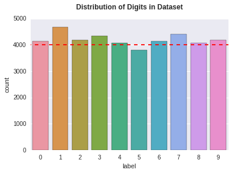

```python
ax = sns.countplot(data = df_full, x = "label");
ax.plot([-1, 0,1,2,3,4,5,6,7,8,9,10], [4000] * 12,'r--')
plt.title("Distribution of Digits in Dataset", y  = 1.05, fontweight = 'bold');
```

```python
df_full['label'].value_counts().sort_index()
```

```
0    4132
1    4684
2    4177
3    4351
4    4072
5    3795
6    4137
7    4401
8    4063
9    4188
Name: label, dtype: int64
```

So what do the digits look like in the dataset? If you downloaded the files off my github, you can run the below cell to see a random digit from the dataset. I also report the actual label of the image.

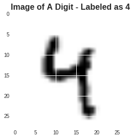

```python
#Use the digit_viewer library to print a random image from the dataset
randrow = np.random.randint(1, len(df) + 1)
img = reshape_image(randrow, df)
print_image(img, get_label(randrow, df_labels))
```

Another thing interesting to see is what the average image looks like in the dataset. This may give us an indication to what the algorithms might come up with in the K-Means and K-Neighbors classifiers. We can also see the most commonly dark pixels for each label type. These may be important pixels which our algorithms will use to predict an image as a particular label.

For example, the dark spot in the average image for label 5 is pretty unique looking among the average digits.

```python
# Create dictionary of average images
avg_img_dict = dict()
for i in range(10):
    avg_img_dict[i] = summary_utils.avg_img(df_full, i)
```

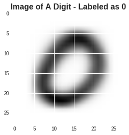

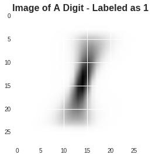

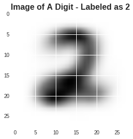

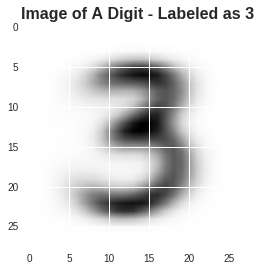

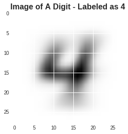

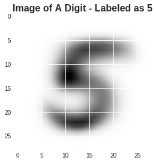

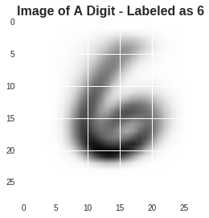

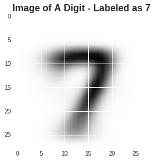

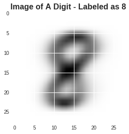

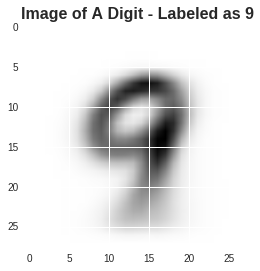

```python
# Printed digits below
for i in range(10):
    print_image(avg_img_dict[i], i)
```

## Classification

First try a naive classification with a *RandomForestClassifier*, and see how it performs on the training and test sets. A RFC is an ensemble classifier that takes in many decision trees, and picks the most likely classification value from the totality of decision trees. You can read about decision trees [here.](https://en.wikipedia.org/wiki/Decision_tree)

We will see how our classifier performs using scikit-learn's `accuracy_score` function, which is how the digit recognition problem is scored. For the record, it takes in a a list of true labels and a list of predictions and returns the percentage classified correctly.

```python
from sklearn.ensemble import RandomForestClassifier
from sklearn.metrics import accuracy_score
```

```python
test_df = pd.read_csv('data/test.csv', header = 0)
```

```python
valid_cols = []
for i in range(784):
    if len(df['pixel{0}'.format(i)].unique()) > 1:
        valid_cols.append('pixel{0}'.format(i))

df_clean = df[valid_cols]
test_df_clean = test_df[valid_cols]
```

Represent the data as numpy arrays to fit into our sklearn models. I normalize the features by dividing by 255, which is the guaranteed maximum for each.

```python
train_X = df_clean.values/255
train_y = df_labels.values
test_X = test_df_clean.values/255
```

```python
#Fit the model
clf = RandomForestClassifier(n_estimators = 200)
clf.fit(train_X, train_y)
```

```
RandomForestClassifier(bootstrap=True, class_weight=None, criterion='gini',
            max_depth=None, max_features='auto', max_leaf_nodes=None,
            min_samples_leaf=1, min_samples_split=2,
            min_weight_fraction_leaf=0.0, n_estimators=200, n_jobs=1,
            oob_score=False, random_state=None, verbose=0,
            warm_start=False)
```

```python
# What is the model accuracy?
summary_utils.score_classifier(train_y, clf.predict(train_X))
```

```
Training
The score on the data set is 100.0%
------------------------------
```

```
1.0
```

The model accuracy looks to be .... 100% on our training dataset. This seems rather unlikely to generalize to other datasets. I have a sneaking suspicion we have overfit our model. Let's try splitting our training dataset into a 70% training set, 30% validation set. We use sklearn's `train_test_split` function.

```python
from sklearn.cross_validation import train_test_split
X_train, X_test, y_train, y_test = train_test_split(train_X, train_y, test_size=0.3, random_state=42)
```

```python
clf.fit(X_train, y_train)
```

```
RandomForestClassifier(bootstrap=True, class_weight=None, criterion='gini',
            max_depth=None, max_features='auto', max_leaf_nodes=None,
            min_samples_leaf=1, min_samples_split=2,
            min_weight_fraction_leaf=0.0, n_estimators=200, n_jobs=1,
            oob_score=False, random_state=None, verbose=0,
            warm_start=False)
```

```python
print("Train Set")
summary_utils.score_classifier(y_train, clf.predict(X_train))
print("Test Set")
summary_utils.score_classifier(y_test, clf.predict(X_test))
```

```
Train Set
Training
The score on the data set is 100.0%
------------------------------
Test Set
Training
The score on the data set is 96.4%
------------------------------
```

```
0.96357142857142852
```

## Feature Selection

That tells us that on non-training data, our model is giving about 96% accuracy.

```python
from sklearn.feature_selection import SelectPercentile
selector = SelectPercentile(percentile = 50) # Keep 50% of the features
X_train_new = selector.fit_transform(X_train, y_train)
X_test_new = selector.transform(X_test)
```

Now, refit the model. The model seems to have a similar performance with only 50% of the features!

```python
# Now refit the model
clf.fit(X_train_new, y_train)
summary_utils.score_classifier(y_train, clf.predict(X_train_new))
summary_utils.score_classifier(y_test, clf.predict(X_test_new))
```

```
------------------------------
The score on the data set is 100.0%
------------------------------
------------------------------
The score on the data set is 96.4%
------------------------------
```

```
0.96380952380952378
```

Let us do some parameter optimization using SearchCV algorithms to see if we can do better with a RandomForestClassifier. By default it uses 3-fold cross validation, which basically cycles test and train dataset until it finds a model that works best. It splits the data into three pieces, and trains the data on two of the pieces, testing on the other. This is then repeated so that all three pieces are tested. The searcher then selects the classifier with parameters that give the best accuracy score.

It turns out the GridSearch offers no performance advantage over the standard classification, because it does so well on the training set.

```python
from sklearn.grid_search import GridSearchCV
param_dict = {'criterion': ['entropy', 'gini'],
               'min_samples_split': [2,4],
               'random_state': [42],
               'n_jobs': [-1]
             }
clf = RandomForestClassifier(n_estimators=200)
searcher = GridSearchCV(estimator = clf, param_grid = param_dict)
searcher.fit(X_train_new, y_train)
print("Train Set")
summary_utils.score_classifier(y_train, searcher.predict(X_train_new))
print("Test Set")
summary_utils.score_classifier(y_test, searcher.predict(X_test_new))
```

```
Train Set
------------------------------
The score on the data set is 100.0%
------------------------------
Test Set
------------------------------
The score on the data set is 96.1%
------------------------------
```

```
0.96055555555555561
```

Well, that didn't work out so well. Maybe I've hit a wall with this classifier. Let's try some other classifiers, starting with SVM's support vector classifier.

```python
import imp
imp.reload(summary_utils);
```

```python
from sklearn.svm import SVC
clf = SVC()
summary_utils.fit_and_score(clf, X_train_new, y_train, X_test_new, y_test)
```

```
------------------------------
The score on the data set is 94.8%
------------------------------
------------------------------
The score on the data set is 94.1%
------------------------------
```

```
(0.94826530612244897, 0.94055555555555559)
```

Well, about 94% accuracy is ok. Maybe we can do better if we do a GridSearch.

```python
param_dict = {'C': [.1, 1, 5],
               'kernel': ['rbf','poly'],
               'random_state': [42]
             }
clf = SVC()
searcher = GridSearchCV(estimator = clf, param_grid = param_dict)
summary_utils.fit_and_score(searcher, X_train_new, y_train, X_test_new, y_test)
```

```
------------------------------
The score on the data set is 97.3%
------------------------------
------------------------------
The score on the data set is 95.9%
------------------------------
```

```
(0.97275510204081628, 0.95880952380952378)
```

With gridsearch, SVM is looking pretty competitive. It may be worth trying it on the full dataset.

```python
searcher.best_estimator_
```

```
SVC(C=5, cache_size=200, class_weight=None, coef0=0.0,
  decision_function_shape=None, degree=3, gamma='auto', kernel='rbf',
  max_iter=-1, probability=False, random_state=42, shrinking=True,
  tol=0.001, verbose=False)
```

```python
clf = SVC(C = 30, kernel = 'rbf')
summary_utils.fit_and_score(clf, X_train, y_train, X_test, y_test)
```

```
Training
The score on the data set is 98.5%
------------------------------
Testing
The score on the data set is 96.4%
------------------------------
```

```
(0.98462585034013606, 0.96396825396825392)
```

For reference, let's try KMeans (10 clusters), K-Neighbors and then Adaboost (with a base SVM classifier.)

```python
from sklearn.cluster import KMeans
from sklearn.neighbors import KNeighborsClassifier
from sklearn.ensemble import AdaBoostClassifier
```

It turns out K-Means is absolutely awful.

```python
clf = KMeans(n_clusters = 10, n_jobs = -1)
summary_utils.fit_and_score(clf, X_train_new, y_train, X_test_new, y_test)
```

[output not shown]

```
------------------------------
The score on the data set is 5.3%
------------------------------
------------------------------
The score on the data set is 5.1%
------------------------------
```

```
(0.052585034013605439, 0.050555555555555555)
```

KNeighbors seems to do ok, actually.

```python
clf = KNeighborsClassifier(n_jobs = -1)
summary_utils.fit_and_score(clf, X_train_new, y_train, X_test_new, y_test)
```

```
------------------------------
The score on the data set is 97.8%
------------------------------
------------------------------
The score on the data set is 96.6%
------------------------------
```

```
(0.97785714285714287, 0.96579365079365076)
```

Let's try AdaBoost on SVC, say 8 classifiers.

```python
clf = AdaBoostClassifier(base_estimator = SVC(C = 30, kernel = 'rbf'), n_estimators = 8, random_state = 42, algorithm = 'SAMME')
summary_utils.fit_and_score(clf, X_train_new, y_train, X_test_new, y_test)
```

```
------------------------------
The score on the data set is 19.7%
------------------------------
------------------------------
The score on the data set is 19.2%
------------------------------
```

```
(0.19731292517006802, 0.19222222222222221)
```

For a final pass, let's try taking our training set, projecting it onto 75 principal components, keeping half of those more important features, and then taking a look at the performance of a grid-searched KNeighbors classifier, since the default algorithm did so well.

```python
from sklearn.decomposition import PCA
pca = PCA(n_components = 75)
selector = SelectPercentile(percentile = 50) # Keep 50% of the features
```

```python
X_train_new2  = pca.fit_transform(X_train, y_train)
X_test_new2  = pca.transform(X_test)
X_train_new2 = selector.fit_transform(X_train_new2, y_train)
X_test_new2 = selector.transform(X_test_new2)
```

```python
from sklearn.grid_search import GridSearchCV
clf2 = KNeighborsClassifier(n_jobs = -1)
param_dict= {'weights': ['uniform', 'distance'],
             'p' : [1,2],
             'n_jobs': [-1]
            }
searcher = GridSearchCV(estimator = clf2, param_grid = param_dict, n_jobs = -1)
summary_utils.fit_and_score(searcher, X_train_new2, y_train, X_test_new2, y_test)
```

[output not shown]

```
Training
The score on the data set is 100.0%
------------------------------
Testing
The score on the data set is 97.2%
------------------------------
```

```
(1.0, 0.97150793650793654)
```

```python
clf = AdaBoostClassifier(base_estimator = SVC(kernel = 'rbf'), n_estimators = 8, random_state = 42, algorithm = 'SAMME')
summary_utils.fit_and_score(clf, X_train_new2, y_train, X_test_new2, y_test)
```

```
Training
The score on the data set is 11.2%
------------------------------
Testing
The score on the data set is 11.0%
------------------------------
```

```
(0.11207482993197279, 0.11023809523809523)
```

```python
searcher.best_estimator_
```

```
KNeighborsClassifier(algorithm='auto', leaf_size=30, metric='minkowski',
           metric_params=None, n_jobs=-1, n_neighbors=5, p=2,
           weights='distance')
```

```python
baseclf = KNeighborsClassifier(algorithm='auto', leaf_size=30, metric='minkowski',
           metric_params=None, n_jobs=-1, n_neighbors=5, p=2,
           weights='distance')
```

Let's try training the KNeighbors Classifier on the full dataset, using the same gridsearch technique.

```python
#searcher_best = searcher.best_estimator_
pca = PCA(n_components = 75)
selector = SelectPercentile(percentile = 50) # Keep 50% of the features
X_train_final = pca.fit_transform(train_X, train_y)
X_test_final = pca.transform(test_X)

X_train_final = selector.fit_transform(X_train_final, train_y)
X_test_final = selector.transform(X_test_final)

final_searcher = GridSearchCV(baseclf, param_grid = param_dict, n_jobs = -1)
final_searcher.fit(X_train_final, train_y)
preds = final_searcher.predict(X_test_final)
```

[output not shown]

Organize the data into a dataframe so we can export it easily.

```python
output_df = pd.DataFrame(preds, columns = ['Label'])
output_df['ImageId'] = output_df.index + 1
output_df = output_df[['ImageId', 'Label']]
output_df.head()
```

|  | ImageId | Label |
| --- | --- | --- |
| 0 | 1 | 2 |
| 1 | 2 | 0 |
| 2 | 3 | 9 |
| 3 | 4 | 2 |
| 4 | 5 | 3 |

Finally output the data to csv.

```python
output_df.to_csv('data/output.csv', header = True, index = False)
```

It turns out that this gives us about 97.4% accuracy on the Kaggle test dataset. Fin!